# Final Project

### The Data

We will be using data that has extensive information on secondary school students in their math class.

```r
data <- read.csv("data/student-mat.csv")
```

### Creation of New Variables

In order to provide more insight, we saw room to create informative variables based upon the given data.

The given variables Medu and Fedu give information about the student’s parents education history. Using this, we created a new variable “first_gen_college” that indicates if the student would be a first generation college student if they decided to pursue higher education. This will give more tangible and clear insight to how parental education impacts student’s performance.

```r
data <- data %>%
  mutate(first_gen_college = case_when(
    Medu < 4 & Fedu < 4 ~ "yes",
    TRUE ~"no"
  ))
```

Additionally, many variables are self reported ratings from the students on a scale of 1-5. We decided that instead factoring these variables so that scores of 1-3 would be “low” and scores of 4-5 would be “high” would be beneficial to our analysis as it would be more interpretable in context.

```r
data <- data %>%
  mutate(famrel = case_when(
    famrel == 1 ~ "low",
    famrel == 2 ~ "low",
    famrel == 3 ~ "low",
    famrel == 4 ~ "high",
    famrel == 5 ~"high"
  ))

data <- data %>%
  mutate(freetime = case_when(
    freetime == 1 ~ "low",
    freetime == 2 ~ "low",
    freetime == 3 ~ "low",
    freetime == 4 ~ "high",
    freetime == 5 ~"high"
  ))

data <- data %>%
  mutate(goout = case_when(
    goout == 1 ~ "low",
    goout == 2 ~ "low",
    goout == 3 ~ "low",
    goout == 4 ~ "high",
    goout == 5 ~"high"
  ))

data <- data %>%
  mutate(Dalc = case_when(
    Dalc == 1 ~ "low",
    Dalc == 2 ~ "low",
    Dalc == 3 ~ "low",
    Dalc == 4 ~ "high",
    Dalc == 5 ~"high"
  ))

data <- data %>%
  mutate(Walc = case_when(
    Walc == 1 ~ "low",
    Walc == 2 ~ "low",
    Walc == 3 ~ "low",
    Walc == 4 ~ "high",
    Walc == 5 ~"high"
  ))

data <- data %>%
  mutate(health = case_when(
    health == 1 ~ "low",
    health == 2 ~ "low",
    health == 3 ~ "low",
    health == 4 ~ "high",
    health == 5 ~"high"
  ))
```

Additionally, using information from the famsup and internet variables, we created a variable called “stable_learning_env”. If famsup is “yes” and internet is “yes”, then stable_learning_env is “yes”, otherwise “no”.

```r
data <- data %>%
  mutate(stable_learning_env = case_when(
    internet =="yes" & famsup =="yes" ~"yes",
    TRUE ~"no"
  ))
```

Also, we created a new variable “high_freq_absent”, which if absences >= 10 for a student, we considered them a highly frequent student.

```r
data <- data %>%
  mutate(high_freq_absent = case_when(
    absences >= 10 ~"yes",
    TRUE ~"no"
  ))
```

We also created a “failed” variable, which was “yes” if failures > 0, and “no” otherwise.

```r
data <- data %>%
  mutate(failed = case_when(
    failures > 0 ~"yes",
    TRUE ~"no"
  ))
```

### Exploratory Data Analysis

```r
summary(data)
```

```
##     school              sex                 age         address
##  Length:395         Length:395         Min.   :15.0   Length:395
##  Class :character   Class :character   1st Qu.:16.0   Class :character
##  Mode  :character   Mode  :character   Median :17.0   Mode  :character
##                                        Mean   :16.7
##                                        3rd Qu.:18.0
##                                        Max.   :22.0
##    famsize            Pstatus               Medu            Fedu
##  Length:395         Length:395         Min.   :0.000   Min.   :0.000
##  Class :character   Class :character   1st Qu.:2.000   1st Qu.:2.000
##  Mode  :character   Mode  :character   Median :3.000   Median :2.000
##                                        Mean   :2.749   Mean   :2.522
##                                        3rd Qu.:4.000   3rd Qu.:3.000
##                                        Max.   :4.000   Max.   :4.000
##      Mjob               Fjob              reason            guardian
##  Length:395         Length:395         Length:395         Length:395
##  Class :character   Class :character   Class :character   Class :character
##  Mode  :character   Mode  :character   Mode  :character   Mode  :character
##
##
##
##    traveltime      studytime        failures       schoolsup
##  Min.   :1.000   Min.   :1.000   Min.   :0.0000   Length:395
##  1st Qu.:1.000   1st Qu.:1.000   1st Qu.:0.0000   Class :character
##  Median :1.000   Median :2.000   Median :0.0000   Mode  :character
##  Mean   :1.448   Mean   :2.035   Mean   :0.3342
##  3rd Qu.:2.000   3rd Qu.:2.000   3rd Qu.:0.0000
##  Max.   :4.000   Max.   :4.000   Max.   :3.0000
##     famsup              paid            activities          nursery
##  Length:395         Length:395         Length:395         Length:395
##  Class :character   Class :character   Class :character   Class :character
##  Mode  :character   Mode  :character   Mode  :character   Mode  :character
##
##
##
##     higher            internet           romantic            famrel
##  Length:395         Length:395         Length:395         Length:395
##  Class :character   Class :character   Class :character   Class :character
##  Mode  :character   Mode  :character   Mode  :character   Mode  :character
##
```

[output cut: 15 more lines]

```
##                     Max.   :75.000   Max.   :19.00   Max.   :19.00
##        G3        first_gen_college  stable_learning_env high_freq_absent
##  Min.   : 0.00   Length:395         Length:395          Length:395
##  1st Qu.: 8.00   Class :character   Class :character    Class :character
##  Median :11.00   Mode  :character   Mode  :character    Mode  :character
##  Mean   :10.42
##  3rd Qu.:14.00
##  Max.   :20.00
##     failed
##  Length:395
##  Class :character
##  Mode  :character
##
##
##
```

First, I will start off with univariate and bivariate plots of the response variable and key predictors I see being important.

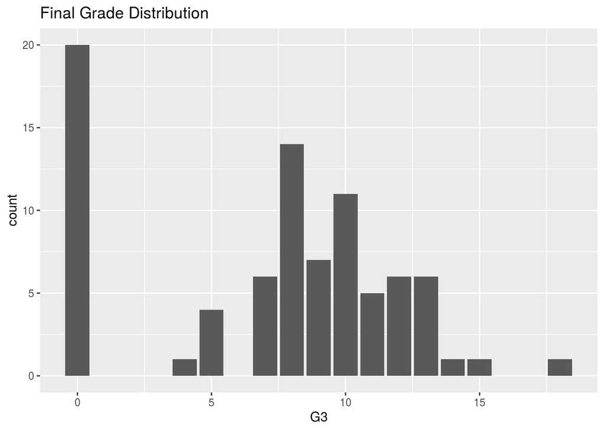

```r
data %>%
  filter(failed =="yes") %>%
  ggplot(aes(G3)) +
  geom_histogram(stat = "count") +
  labs(title="Final Grade Distribution")
```

[figure not shown]

```r
data %>%
  filter(failed =="yes") %>%
  ggplot(aes(G3)) +
  geom_histogram(stat = "count") +
  labs(title="Final Grade Distribution")
```

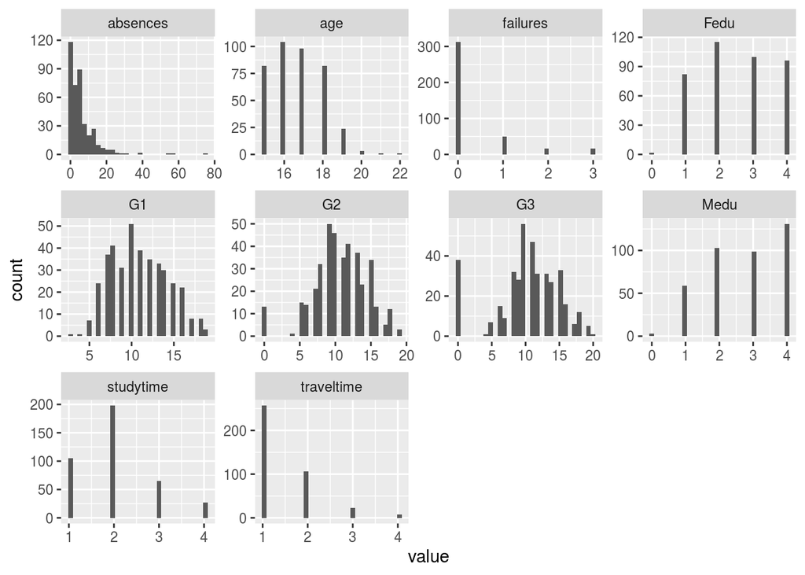

```r
data %>%
  keep(is.numeric) %>%
  gather() %>%
  ggplot(aes(value)) +
    facet_wrap(~ key, scales = "free") +
    geom_histogram()
```

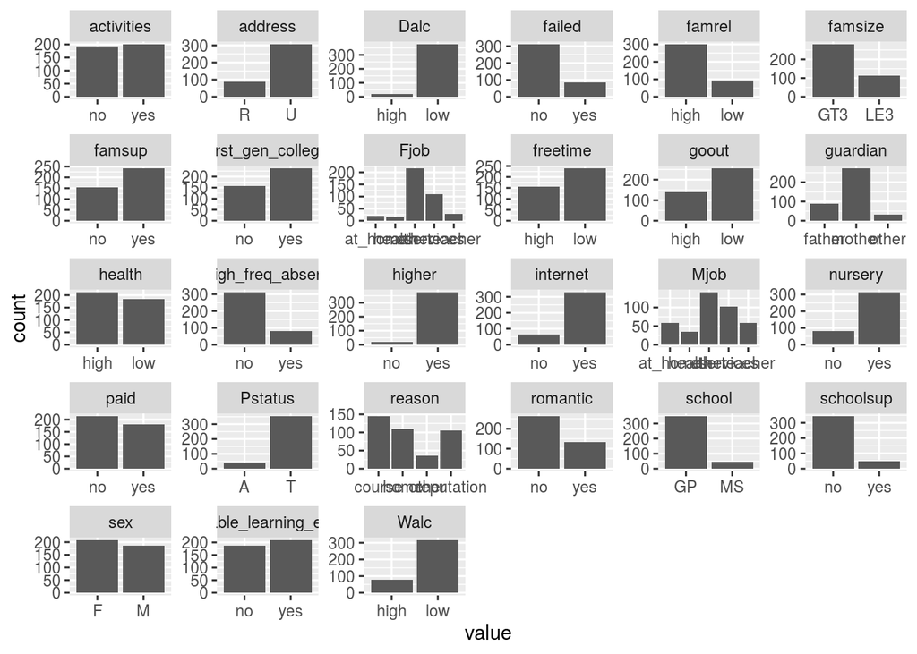

```r
data %>%
  keep(is.character) %>%
  gather() %>%
  ggplot(aes(value)) +
    facet_wrap(~ key, scales = "free") +
    geom_histogram(stat="count")
```

Above we see that the response variable, G3, is pretty normally distributed, thus no transformation is necessary,

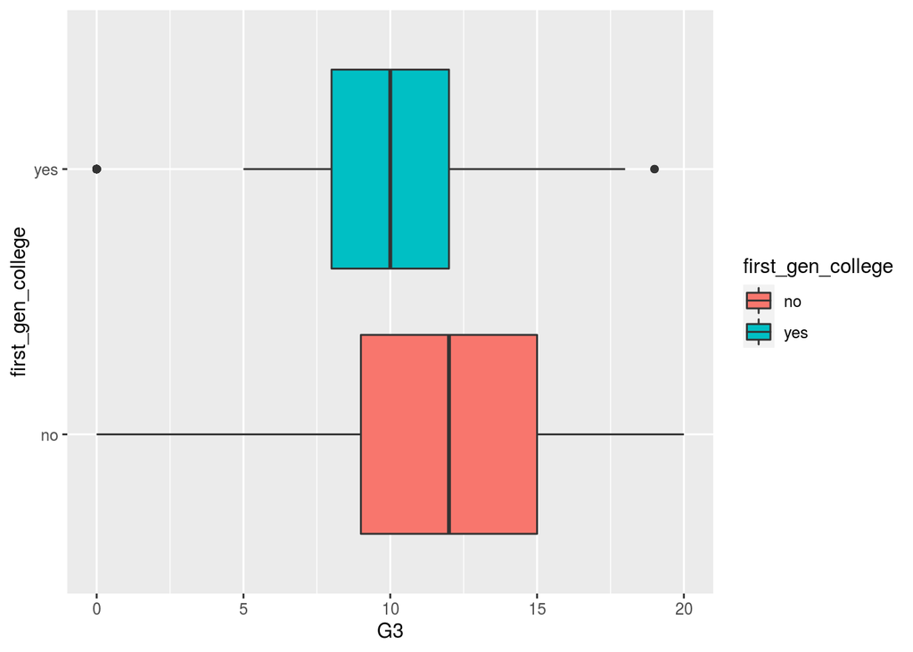

```r
ggplot(data = data, aes(x = G3, y = first_gen_college, fill=first_gen_college)) +
  geom_boxplot()
```

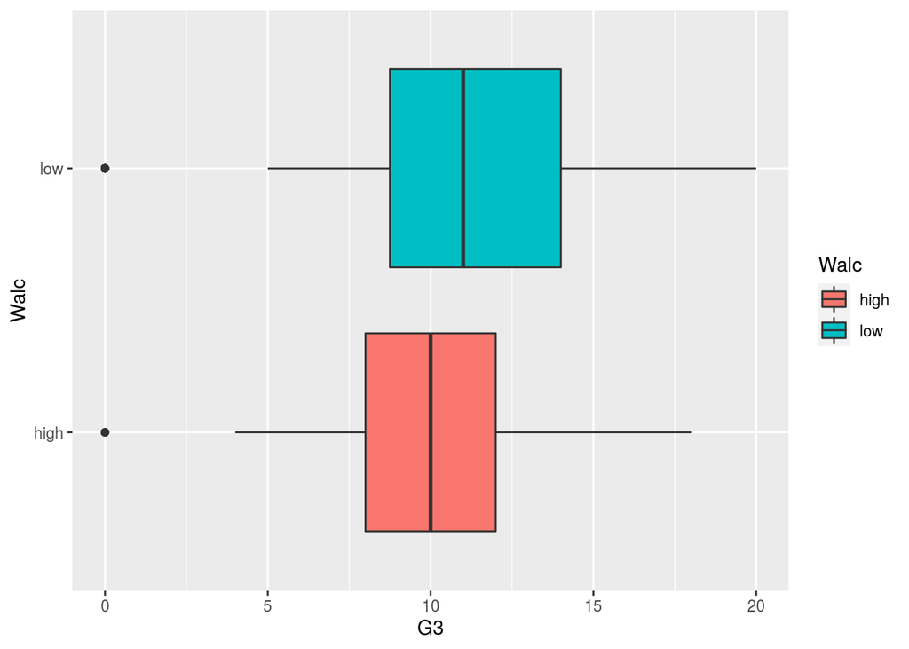

```r
ggplot(data = data, aes(x = G3, y = Walc, fill = Walc)) +
  geom_boxplot()
```

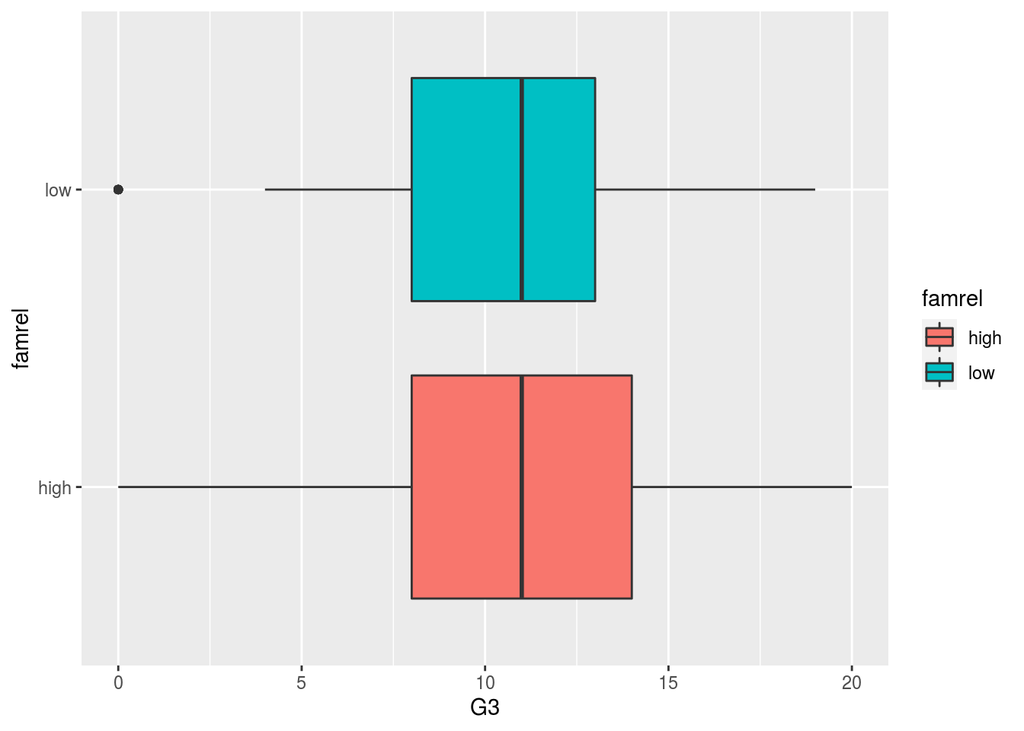

```r
ggplot(data = data, aes(x = G3, y = famrel, fill = famrel)) +
  geom_boxplot()
```

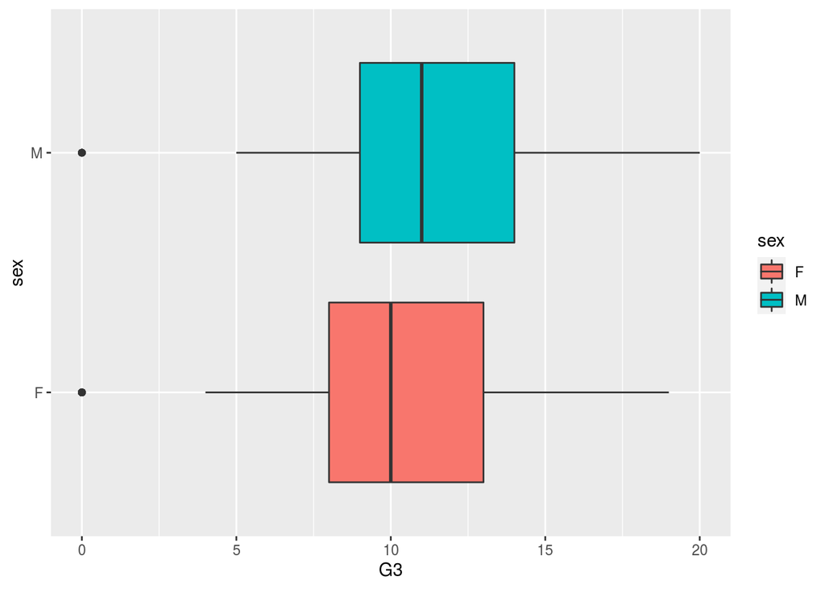

```r
ggplot(data = data, aes(x = G3, y= sex, fill = sex)) +
  geom_boxplot()
```

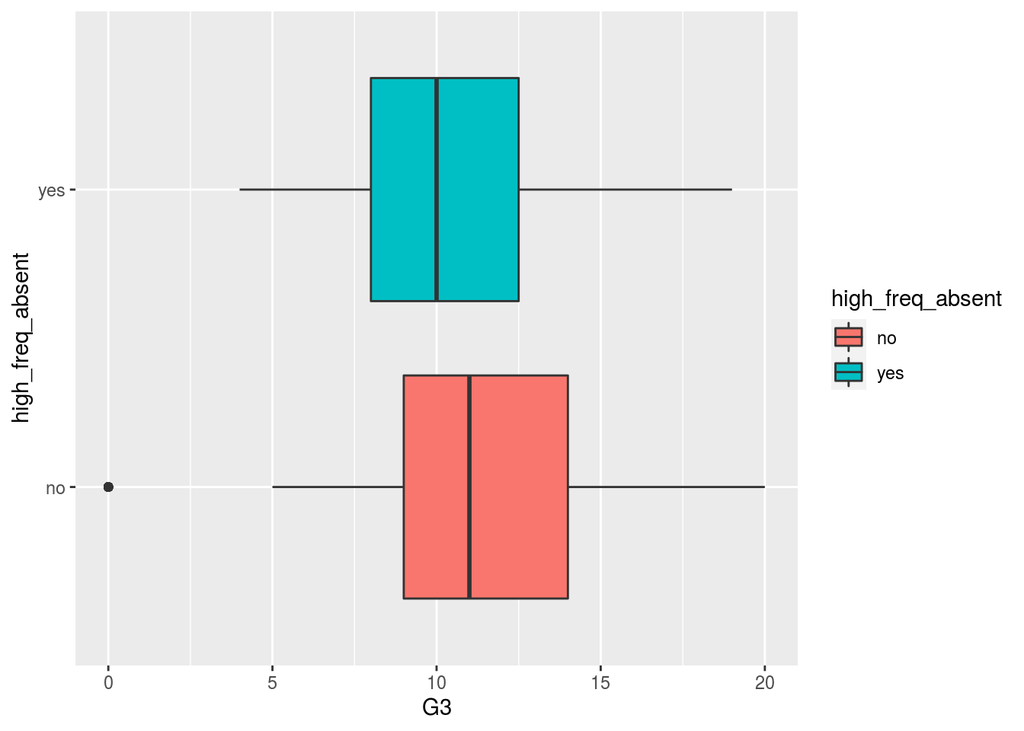

```r
ggplot(data = data, aes(x = G3, y = high_freq_absent, fill = high_freq_absent)) +
  geom_boxplot()
```

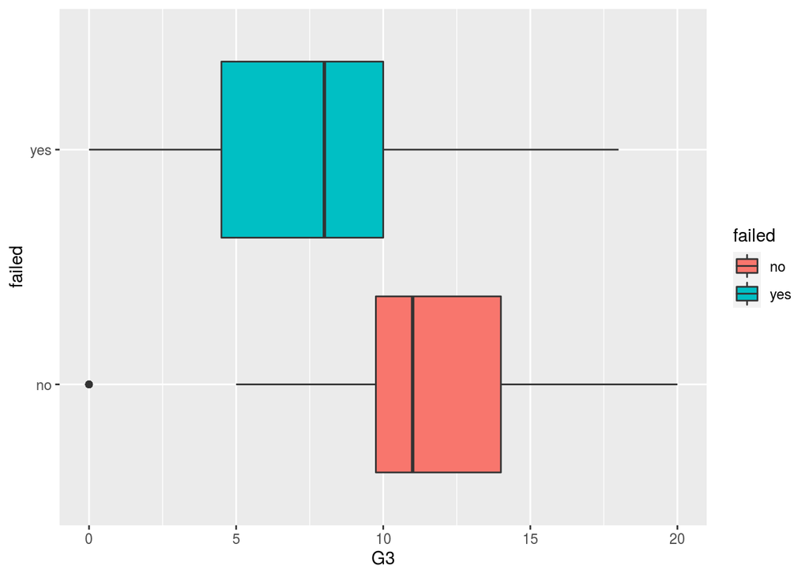

```r
ggplot(data = data, aes(x = G3, y=failed, fill = failed)) +
  geom_boxplot()
```

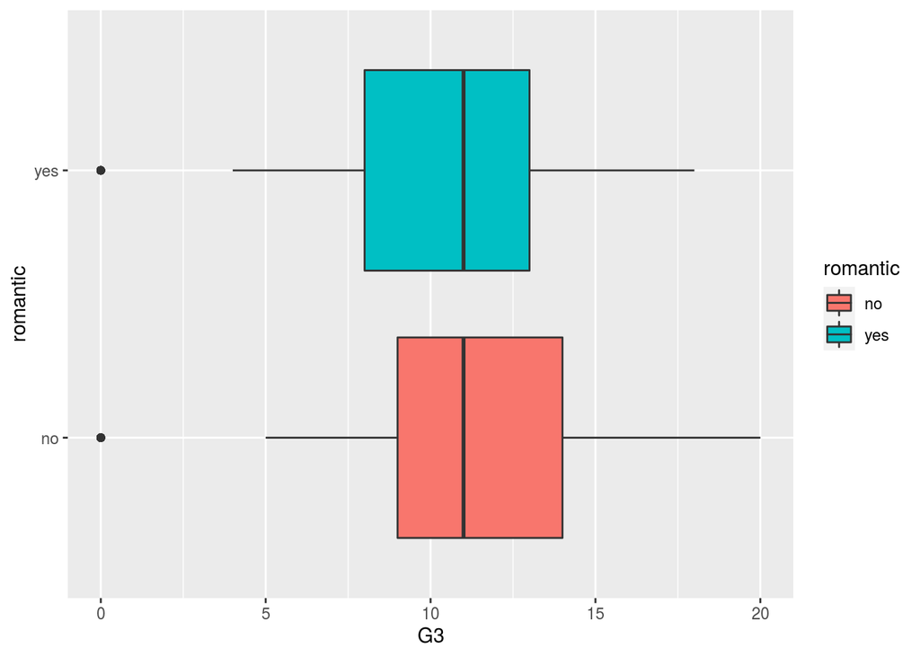

```r
ggplot(data = data, aes(x = G3, y=romantic, fill = romantic)) +
  geom_boxplot()
```

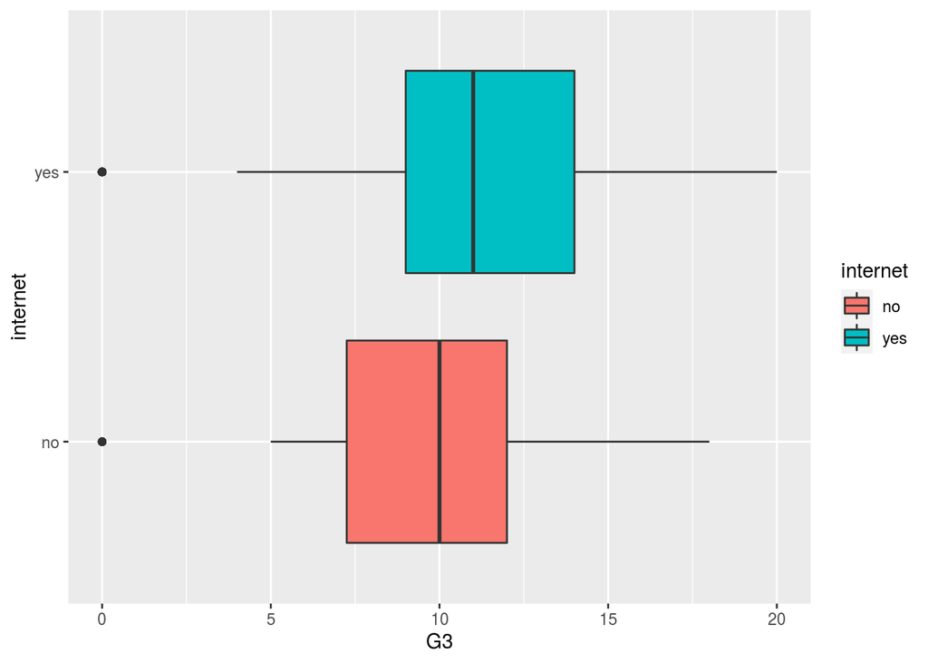

```r
ggplot(data = data, aes(x = G3, y=internet, fill = internet)) +
  geom_boxplot()
```

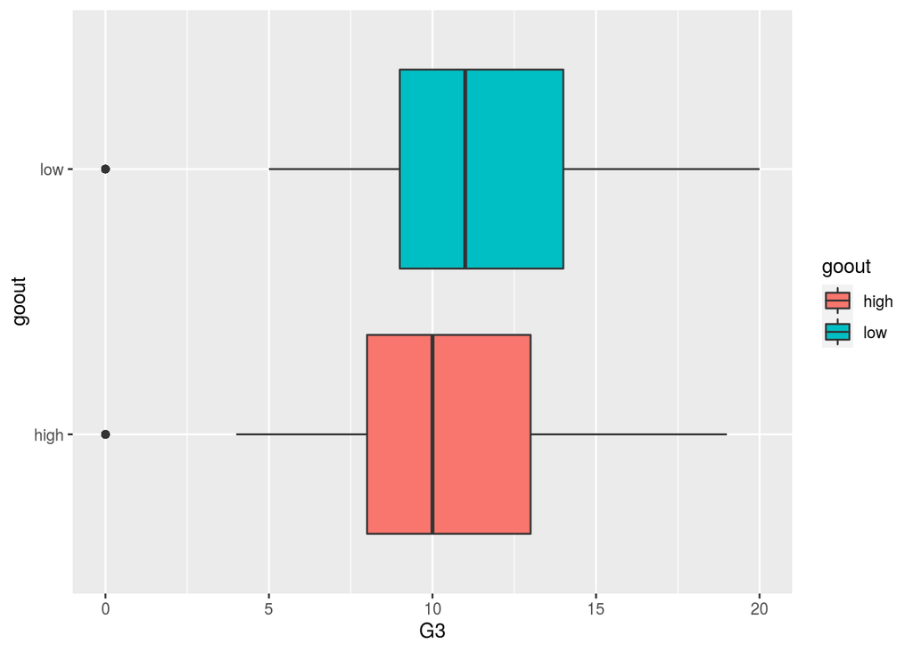

```r
ggplot(data = data, aes(x = G3, y=goout, fill = goout)) +
  geom_boxplot()
```

From the initial explorations above, we can see a few possible trends. Students who had at least one of the following traits: failed a class previously, were a highly frequent absent student, frequently went out, without internet, were frequent drinkers on the weekend, were in romantic relationships, and were first generation students, on average had lower final grades than their counterparts.

```r
names(data)
```

```
##  [1] "school"              "sex"                 "age"
##  [4] "address"             "famsize"             "Pstatus"
##  [7] "Medu"                "Fedu"                "Mjob"
## [10] "Fjob"                "reason"              "guardian"
## [13] "traveltime"          "studytime"           "failures"
## [16] "schoolsup"           "famsup"              "paid"
## [19] "activities"          "nursery"             "higher"
## [22] "internet"            "romantic"            "famrel"
## [25] "freetime"            "goout"               "Dalc"
## [28] "Walc"                "health"              "absences"
## [31] "G1"                  "G2"                  "G3"
## [34] "first_gen_college"   "stable_learning_env" "high_freq_absent"
## [37] "failed"
```

```r
num_cols <- unlist(lapply(data, is.numeric))
quant_vars <- data[,num_cols]
cor(quant_vars)
```

```
##                     age        Medu         Fedu  traveltime    studytime
## age         1.000000000 -0.16365842 -0.163438069  0.07064072 -0.004140037
## Medu       -0.163658419  1.00000000  0.623455112 -0.17163930  0.064944137
## Fedu       -0.163438069  0.62345511  1.000000000 -0.15819405 -0.009174639
## traveltime  0.070640721 -0.17163930 -0.158194054  1.00000000 -0.100909119
## studytime  -0.004140037  0.06494414 -0.009174639 -0.10090912  1.000000000
## failures    0.243665377 -0.23667996 -0.250408444  0.09223875 -0.173563031
## absences    0.175230079  0.10028482  0.024472887 -0.01294378 -0.062700175
## G1         -0.064081497  0.20534100  0.190269936 -0.09303999  0.160611915
## G2         -0.143474049  0.21552717  0.164893393 -0.15319796  0.135879999
## G3         -0.161579438  0.21714750  0.152456939 -0.11714205  0.097819690
##               failures    absences          G1         G2          G3
## age         0.24366538  0.17523008 -0.06408150 -0.1434740 -0.16157944
## Medu       -0.23667996  0.10028482  0.20534100  0.2155272  0.21714750
## Fedu       -0.25040844  0.02447289  0.19026994  0.1648934  0.15245694
## traveltime  0.09223875 -0.01294378 -0.09303999 -0.1531980 -0.11714205
## studytime  -0.17356303 -0.06270018  0.16061192  0.1358800  0.09781969
## failures    1.00000000  0.06372583 -0.35471761 -0.3558956 -0.36041494
## absences    0.06372583  1.00000000 -0.03100290 -0.0317767  0.03424732
## G1         -0.35471761 -0.03100290  1.00000000  0.8521181  0.80146793
## G2         -0.35589563 -0.03177670  0.85211807  1.0000000  0.90486799
## G3         -0.36041494  0.03424732  0.80146793  0.9048680  1.00000000
```

```r
#library(corr)
#quant_vars %>% correlate() %>% network_plot(min_cor=0.2)
```

## Splitting data into training and testing sets

```r
data <- data %>%
  mutate(ord_g3 = factor(G3, ordered=T)
  )
data$ord_g3
```

```
##   [1] 6  6  10 15 10 15 11 6  19 15 9  12 14 11 16 14 14 10 5  10 15 15 16 12 8
##  [26] 8  11 15 11 11 12 17 16 12 15 6  18 15 11 13 11 12 18 11 9  6  11 20 14 7
##  [51] 13 13 10 11 13 10 15 15 9  16 11 11 9  9  10 15 12 6  8  16 15 10 5  14 11
##  [76] 10 10 11 10 5  12 11 6  15 10 8  6  14 10 7  8  18 6  10 14 10 15 10 14 8
## [101] 5  17 14 6  18 11 8  18 13 16 19 10 13 19 9  16 14 13 8  13 15 15 13 13 8
## [126] 12 11 9  0  18 0  0  12 11 0  0  0  0  12 15 0  9  11 13 0  11 0  11 0  10
## [151] 0  14 10 0  12 8  13 10 15 12 0  7  0  10 7  12 10 16 0  14 0  16 10 0  9
## [176] 9  11 6  9  11 8  12 17 8  12 11 11 15 9  10 13 9  8  10 14 15 16 10 18 10
## [201] 16 10 10 6  11 9  7  13 10 7  8  13 14 8  10 15 4  8  8  10 6  0  17 13 14
## [226] 7  15 12 9  12 14 11 9  13 6  10 13 12 11 0  12 12 0  12 0  18 13 8  5  15
## [251] 8  10 8  8  12 8  13 11 14 0  18 8  12 9  0  17 10 11 10 0  9  14 11 14 10
## [276] 12 9  9  8  10 8  10 12 10 11 11 19 12 14 15 11 15 13 18 14 11 0  8  14 16
## [301] 11 10 14 18 13 12 18 8  12 10 0  13 11 11 13 11 0  9  10 11 13 9  11 15 15
## [326] 11 16 10 9  14 8  14 0  0  0  15 13 0  17 10 11 0  15 0  10 14 16 9  15 13
## [351] 8  13 8  8  11 9  13 11 10 16 13 12 10 15 12 10 13 0  10 11 9  12 11 5  19
## [376] 10 15 10 15 10 14 7  10 0  5  10 6  0  8  0  9  16 7  10 9
## 18 Levels: 0 < 4 < 5 < 6 < 7 < 8 < 9 < 10 < 11 < 12 < 13 < 14 < 15 < ... < 20
```

```r
attach(data)
set.seed(3)
train_ind <- sample(x = nrow(data), size = 0.8 * nrow(data))
test_ind_neg <- -train_ind
training <- data[train_ind, ]
testing <- data[test_ind_neg, ]
training
```

```
##     school sex age address famsize Pstatus Medu Fedu     Mjob     Fjob
## 261     GP   F  18       U     GT3       T    4    3 services    other
## 186     GP   M  17       U     GT3       T    3    3 services services
## 140     GP   F  15       U     GT3       T    4    4  teacher  teacher
## 36      GP   F  15       U     GT3       T    2    3    other    other
## 394     MS   M  18       R     LE3       T    3    2 services    other
## 363     MS   F  18       U     GT3       T    3    3 services services
## 276     GP   F  17       U     LE3       T    2    2 services    other
## 330     GP   F  17       U     GT3       T    4    4  teacher  teacher
## 183     GP   F  17       U     GT3       T    2    4 services services
## 168     GP   F  16       U     GT3       T    4    2   health services
## 48      GP   M  16       U     GT3       T    4    3   health services
## 104     GP   F  15       U     GT3       T    3    2 services    other
## 136     GP   F  15       U     GT3       T    4    4 services  at_home
## 37      GP   M  15       U     LE3       T    4    3  teacher services
```

[output cut: 1570 more lines]

```r
testing
```

```
##     school sex age address famsize Pstatus Medu Fedu     Mjob     Fjob
## 11      GP   F  15       U     GT3       T    4    4  teacher   health
## 17      GP   F  16       U     GT3       T    4    4 services services
## 18      GP   F  16       U     GT3       T    3    3    other    other
## 21      GP   M  15       U     GT3       T    4    3  teacher    other
## 31      GP   M  15       U     GT3       T    4    4   health services
## 32      GP   M  15       U     GT3       T    4    4 services services
## 34      GP   M  15       U     LE3       T    3    3    other    other
## 43      GP   M  15       U     GT3       T    4    4 services  teacher
## 46      GP   F  15       U     LE3       A    4    3    other    other
## 58      GP   M  15       U     GT3       T    4    4  teacher   health
## 59      GP   M  15       U     LE3       T    1    2    other  at_home
## 60      GP   F  16       U     GT3       T    4    2 services    other
## 72      GP   M  15       U     GT3       T    4    2    other    other
## 76      GP   M  15       U     GT3       T    4    3  teacher    other
```

[output cut: 385 more lines]

## Linear model

Modeling, diagnostics, predictions

```r
base_lm <- lm(G3 ~ . -G2 -G1 -ord_g3 -stable_learning_env, data)
summary(base_lm)
```

```
##
## Call:
## lm(formula = G3 ~ . - G2 - G1 - ord_g3 - stable_learning_env,
##     data = data)
##
## Residuals:
##      Min       1Q   Median       3Q      Max
## -12.4629  -1.8563   0.3768   2.7129   8.4183
##
## Coefficients:
##                      Estimate Std. Error t value Pr(>|t|)
## (Intercept)          14.26449    4.83968   2.947  0.00342 **
## schoolMS              0.71627    0.78940   0.907  0.36483
## sexM                  1.24064    0.49743   2.494  0.01309 *
## age                  -0.29977    0.21631  -1.386  0.16667
## addressU              0.50527    0.57951   0.872  0.38386
## famsizeLE3            0.70815    0.48336   1.465  0.14380
## PstatusT             -0.33706    0.72697  -0.464  0.64318
## Medu                  0.19327    0.35893   0.538  0.59060
## Fedu                 -0.24782    0.30312  -0.818  0.41416
## Mjobhealth            0.77671    1.11854   0.694  0.48789
## Mjobother            -0.37068    0.71864  -0.516  0.60631
## Mjobservices          0.77141    0.79944   0.965  0.33524
## Mjobteacher          -1.45523    1.04350  -1.395  0.16402
## Fjobhealth            0.50264    1.43071   0.351  0.72556
## Fjobother            -0.44303    1.01109  -0.438  0.66153
## Fjobservices         -0.28558    1.05170  -0.272  0.78614
## Fjobteacher           1.18454    1.28968   0.918  0.35900
## reasonhome            0.15104    0.55120   0.274  0.78422
## reasonother           0.90615    0.81174   1.116  0.26505
## reasonreputation      0.78970    0.57320   1.378  0.16917
## guardianmother       -0.06654    0.54705  -0.122  0.90326
## guardianother         0.74621    0.99921   0.747  0.45568
## traveltime           -0.33731    0.34177  -0.987  0.32435
## studytime             0.43921    0.28472   1.543  0.12382
## failures             -0.68669    0.59765  -1.149  0.25134
## schoolsupyes         -1.25886    0.66531  -1.892  0.05929 .
## famsupyes            -0.87494    0.47671  -1.835  0.06729 .
## paidyes               0.27979    0.47654   0.587  0.55749
## activitiesyes        -0.27894    0.44015  -0.634  0.52667
## nurseryyes           -0.12389    0.54987  -0.225  0.82188
## higheryes             1.48003    1.08166   1.368  0.17209
## internetyes           0.45356    0.61399   0.739  0.46058
## romanticyes          -1.16064    0.46719  -2.484  0.01345 *
## famrellow            -0.30748    0.51272  -0.600  0.54909
## freetimelow          -0.79441    0.47382  -1.677  0.09450 .
## gooutlow              1.33550    0.51112   2.613  0.00936 **
## Dalclow              -0.21717    1.15359  -0.188  0.85079
## Walclow              -0.02676    0.67033  -0.040  0.96818
## healthlow             0.20864    0.44481   0.469  0.63932
## absences              0.09519    0.04094   2.325  0.02063 *
## first_gen_collegeyes -1.02075    0.79309  -1.287  0.19892
## high_freq_absentyes  -0.77063    0.81373  -0.947  0.34427
## failedyes            -2.27412    1.10329  -2.061  0.04002 *
## ---
## Signif. codes:  0 '***' 0.001 '**' 0.01 '*' 0.05 '.' 0.1 ' ' 1
##
## Residual standard error: 4.082 on 352 degrees of freedom
## Multiple R-squared:  0.2907, Adjusted R-squared:  0.2061
## F-statistic: 3.435 on 42 and 352 DF,  p-value: 1.498e-10
```

```r
step.model <- stepAIC(base_lm, direction="both")
```

```
## Start:  AIC=1151.72
## G3 ~ (school + sex + age + address + famsize + Pstatus + Medu +
##     Fedu + Mjob + Fjob + reason + guardian + traveltime + studytime +
##     failures + schoolsup + famsup + paid + activities + nursery +
##     higher + internet + romantic + famrel + freetime + goout +
##     Dalc + Walc + health + absences + G1 + G2 + first_gen_college +
##     stable_learning_env + high_freq_absent + failed + ord_g3) -
##     G2 - G1 - ord_g3 - stable_learning_env
##
##                     Df Sum of Sq    RSS    AIC
## - Fjob               4    58.108 5924.0 1147.6
## - guardian           2    12.927 5878.8 1148.6
## - reason             3    46.316 5912.2 1148.8
## - Walc               1     0.027 5865.9 1149.7
## - Dalc               1     0.591 5866.5 1149.8
## - nursery            1     0.846 5866.7 1149.8
## - Pstatus            1     3.582 5869.5 1150.0
## - health             1     3.666 5869.6 1150.0
## - Medu               1     4.832 5870.7 1150.0
## - paid               1     5.745 5871.6 1150.1
## - famrel             1     5.993 5871.9 1150.1
## - activities         1     6.693 5872.6 1150.2
## - internet           1     9.094 5875.0 1150.3
## - Fedu               1    11.139 5877.0 1150.5
## - address            1    12.668 5878.6 1150.6
## - school             1    13.720 5879.6 1150.6
## - high_freq_absent   1    14.946 5880.8 1150.7
## - traveltime         1    16.232 5882.1 1150.8
## - failures           1    22.000 5887.9 1151.2
## - first_gen_college  1    27.605 5893.5 1151.6
## <none>                           5865.9 1151.7
## - higher             1    31.200 5897.1 1151.8
## - age                1    32.006 5897.9 1151.9
## - famsize            1    35.768 5901.7 1152.1
## - studytime          1    39.656 5905.5 1152.4
## - freetime           1    46.845 5912.7 1152.9
## - famsup             1    56.136 5922.0 1153.5
## - schoolsup          1    59.662 5925.6 1153.7
## - failed             1    70.801 5936.7 1154.5
## - absences           1    90.094 5956.0 1155.7
```

[output cut: 834 more lines]

```
## + reason             3     63.85 6089.3 1120.5
## + nursery            1      0.88 6152.3 1120.5
## + Dalc               1      0.33 6152.8 1120.6
## + Fedu               1      0.20 6153.0 1120.6
## + school             1      0.10 6153.1 1120.6
## - studytime          1     64.86 6218.0 1120.8
## - first_gen_college  1     84.51 6237.7 1122.0
## + guardian           2      5.72 6147.4 1122.2
## + Fjob               4     62.03 6091.1 1122.6
## - romantic           1     96.69 6249.9 1122.8
## - sex                1     97.75 6250.9 1122.8
## - absences           1    123.11 6276.3 1124.4
## - Mjob               4    242.27 6395.4 1125.9
## - goout              1    189.15 6342.3 1128.6
## - failed             1    670.10 6823.3 1157.4
```

```r
summary(step.model)
```

```
##
## Call:
## lm(formula = G3 ~ sex + famsize + Mjob + studytime + schoolsup +
##     famsup + higher + romantic + freetime + goout + absences +
##     first_gen_college + failed, data = data)
##
## Residuals:
##      Min       1Q   Median       3Q      Max
## -13.2041  -2.0732   0.3544   2.6786   9.6991
##
## Coefficients:
##                      Estimate Std. Error t value Pr(>|t|)
## (Intercept)           8.11450    1.39218   5.829 1.20e-08 ***
## sexM                  1.12016    0.45712   2.450 0.014719 *
## famsizeLE3            0.65890    0.45713   1.441 0.150309
## Mjobhealth            1.68430    0.93895   1.794 0.073641 .
## Mjobother             0.05209    0.63950   0.081 0.935123
## Mjobservices          1.36030    0.68184   1.995 0.046757 *
## Mjobteacher          -0.71854    0.87864  -0.818 0.413992
## studytime             0.52329    0.26215   1.996 0.046634 *
## schoolsupyes         -0.94383    0.62288  -1.515 0.130542
## famsupyes            -0.80258    0.43716  -1.836 0.067160 .
## higheryes             1.73643    0.99609   1.743 0.082102 .
## romanticyes          -1.09643    0.44989  -2.437 0.015265 *
## freetimelow          -0.84135    0.44848  -1.876 0.061429 .
## gooutlow              1.53330    0.44981   3.409 0.000723 ***
## absences              0.07208    0.02621   2.750 0.006245 **
## first_gen_collegeyes -1.19608    0.52493  -2.279 0.023250 *
## failedyes            -3.51954    0.54855  -6.416 4.19e-10 ***
## ---
## Signif. codes:  0 '***' 0.001 '**' 0.01 '*' 0.05 '.' 0.1 ' ' 1
##
## Residual standard error: 4.035 on 378 degrees of freedom
## Multiple R-squared:  0.256,  Adjusted R-squared:  0.2245
## F-statistic: 8.127 on 16 and 378 DF,  p-value: < 2.2e-16
```

From fitting the base variables in a linear model, we can see that the variables sex, schoolsup, famsup, romantic, freetime, goout, absences, and failed are active.

Based on the backwards stepwise regression model, it seems that the variables sex, Mjob, studytime, higher, romantic, freetime, goout, absences, first_gen_college, famsup, failed.

Based on these active variables, some interactions that we think could be significant are: schoolsup*failed, famsup*first_gen_college, higher*first_gen_college.

```r
activelm <- lm(G3 ~ (sex + schoolsup + romantic + freetime + goout + absences + failed + Mjob + studytime + higher + first_gen_college + famsup)^2)

summary(activelm)
```

```
##
## Call:
## lm(formula = G3 ~ (sex + schoolsup + romantic + freetime + goout +
##     absences + failed + Mjob + studytime + higher + first_gen_college +
##     famsup)^2)
##
## Residuals:
##      Min       1Q   Median       3Q      Max
## -13.6429  -1.7534   0.2846   2.2075   7.3177
##
## Coefficients: (2 not defined because of singularities)
##                                     Estimate Std. Error t value Pr(>|t|)
## (Intercept)                        -1.506826  13.118897  -0.115 0.908638
## sexM                                0.892073   5.622189   0.159 0.874042
## schoolsupyes                       13.761155   9.218122   1.493 0.136598
## romanticyes                        -1.449784   4.692335  -0.309 0.757574
## freetimelow                         2.630885   4.451459   0.591 0.554983
## gooutlow                           -1.031107  10.156300  -0.102 0.919207
## absences                            0.148759   0.316984   0.469 0.639221
## failedyes                          -8.234032   4.894235  -1.682 0.093599 .
## Mjobhealth                         -1.259093   5.227716  -0.241 0.809847
## Mjobother                          -5.143290   9.033916  -0.569 0.569585
## Mjobservices                        1.528706  11.532458   0.133 0.894638
## Mjobteacher                        -9.988699   6.801967  -1.469 0.143083
## studytime                           5.357552   4.658888   1.150 0.251133
## higheryes                          15.703850  12.568400   1.249 0.212529
## first_gen_collegeyes               -2.042557   2.769453  -0.738 0.461413
## famsupyes                          -1.124951   5.956632  -0.189 0.850341
## sexM:schoolsupyes                  -3.306582   1.597411  -2.070 0.039366 *
## sexM:romanticyes                    1.516326   1.076859   1.408 0.160203
## sexM:freetimelow                    0.440768   1.021810   0.431 0.666536
## sexM:gooutlow                       0.140986   1.100729   0.128 0.898174
## sexM:absences                      -0.168685   0.101499  -1.662 0.097636 .
## sexM:failedyes                     -0.812131   1.739573  -0.467 0.640963
## sexM:Mjobhealth                     4.072742   2.744648   1.484 0.138956
## sexM:Mjobother                      2.715976   1.700434   1.597 0.111336
## sexM:Mjobservices                   3.912599   1.832894   2.135 0.033651 *
## sexM:Mjobteacher                    4.222718   2.177167   1.940 0.053432 .
## sexM:studytime                     -0.342144   0.612314  -0.559 0.576761
## sexM:higheryes                     -4.325565   5.196762  -0.832 0.405911
```

[output cut: 78 more lines]

```
## Mjobother:famsupyes                 0.228631   1.502886   0.152 0.879195
## Mjobservices:famsupyes             -0.129235   1.643959  -0.079 0.937397
## Mjobteacher:famsupyes              -1.875211   2.166962  -0.865 0.387575
## studytime:higheryes                -7.929807   4.479400  -1.770 0.077760 .
## studytime:first_gen_collegeyes      0.748786   0.744561   1.006 0.315434
## studytime:famsupyes                 1.418357   0.614634   2.308 0.021743 *
## higheryes:first_gen_collegeyes            NA         NA      NA       NA
## higheryes:famsupyes                -1.524942   5.664120  -0.269 0.787951
## first_gen_collegeyes:famsupyes     -1.101570   1.255553  -0.877 0.381039
## ---
## Signif. codes:  0 '***' 0.001 '**' 0.01 '*' 0.05 '.' 0.1 ' ' 1
##
## Residual standard error: 3.84 on 282 degrees of freedom
## Multiple R-squared:  0.4973, Adjusted R-squared:  0.2976
## F-statistic: 2.491 on 112 and 282 DF,  p-value: 5.445e-10
```

From this, we can see that there seem to be significant interaction effects between sex and schoolsup, sex and first_gen_college, sex and Mjob, schoolsup and absences, schoolsup and studytime, schoolsup and first_gen_college, absences and failed, failed and first_gen_college, Mjob and studytime, Mjob and first_gen_college, studytime and famsup.

## Multicategory ordinal logit model

We examine the EDA and active variables in the linear model to choose the predictors in our base model.

Fitting the base model:

```r
require(foreign)
```

```r
require(nnet)
require(ggplot2)
require(reshape2)
```

```r
require(MASS)
require(Hmisc)
```

```r
require(MASS)
require(Hmisc)
```

```r
mod1 <- polr(ord_g3 ~ failed + high_freq_absent + romantic + internet + goout + first_gen_college + Walc + sex + schoolsup + famsup + absences + studytime + higher, data = training)
summary(mod1)
```

```
##
## Re-fitting to get Hessian
```

```
## Call:
## polr(formula = ord_g3 ~ failed + high_freq_absent + romantic +
##     internet + goout + first_gen_college + Walc + sex + schoolsup +
##     famsup + absences + studytime + higher, data = training)
##
## Coefficients:
##                         Value Std. Error t value
## failedyes            -1.34171    0.27018 -4.9659
## high_freq_absentyes   0.03565    0.34970  0.1019
## romanticyes          -0.45766    0.22322 -2.0502
## internetyes           0.36012    0.27651  1.3024
## gooutlow              0.58461    0.22879  2.5552
## first_gen_collegeyes -0.66042    0.22335 -2.9568
## Walclow               0.33622    0.27525  1.2215
## sexM                  0.55216    0.22206  2.4865
## schoolsupyes         -0.69882    0.28905 -2.4177
## famsupyes            -0.48594    0.21594 -2.2503
## absences              0.01048    0.01726  0.6071
## studytime             0.25616    0.13427  1.9078
## higheryes             0.37412    0.45201  0.8277
##
## Intercepts:
##       Value   Std. Error t value
## 0|4   -1.6658  0.6572    -2.5347
## 4|5   -1.6293  0.6566    -2.4816
## 5|6   -1.4556  0.6534    -2.2276
## 6|7   -1.1027  0.6485    -1.7004
## 7|8   -0.9014  0.6467    -1.3939
## 8|9   -0.3219  0.6437    -0.5000
## 9|10   0.0449  0.6427     0.0698
## 10|11  0.6847  0.6438     1.0635
## 11|12  1.2954  0.6464     2.0040
## 12|13  1.6591  0.6479     2.5610
## 13|14  2.1640  0.6516     3.3212
## 14|15  2.6641  0.6579     4.0496
## 15|16  3.3940  0.6711     5.0577
## 16|17  3.9280  0.6858     5.7276
## 17|18  4.2419  0.6982     6.0754
## 18|19  5.2132  0.7670     6.7971
## 19|20  7.0544  1.1934     5.9112
##
## Residual Deviance: 1562.392
## AIC: 1622.392
```

```r
(ctable <- coef(summary(mod1)))
```

```
##
## Re-fitting to get Hessian
```

```
##                            Value Std. Error     t value
## failedyes            -1.34171397 0.27018479 -4.96591237
## high_freq_absentyes   0.03565031 0.34969709  0.10194625
## romanticyes          -0.45766071 0.22322374 -2.05023314
## internetyes           0.36011512 0.27651008  1.30235803
## gooutlow              0.58461188 0.22879147  2.55521711
## first_gen_collegeyes -0.66042320 0.22335452 -2.95683831
## Walclow               0.33622440 0.27525303  1.22151026
## sexM                  0.55215988 0.22206496  2.48647905
## schoolsupyes         -0.69881781 0.28904608 -2.41766920
## famsupyes            -0.48593653 0.21594151 -2.25031553
## absences              0.01047719 0.01725748  0.60710999
## studytime             0.25615867 0.13426713  1.90782854
## higheryes             0.37411910 0.45201352  0.82767238
## 0|4                  -1.66581605 0.65721302 -2.53466683
## 4|5                  -1.62930927 0.65655494 -2.48160386
## 5|6                  -1.45558081 0.65342826 -2.22760613
## 6|7                  -1.10268571 0.64846971 -1.70044290
## 7|8                  -0.90144383 0.64670148 -1.39391027
## 8|9                  -0.32186448 0.64369588 -0.50002569
## 9|10                  0.04485165 0.64272846  0.06978319
## 10|11                 0.68472806 0.64384467  1.06349884
## 11|12                 1.29538659 0.64638677  2.00404255
## 12|13                 1.65914607 0.64785012  2.56100295
## 13|14                 2.16402771 0.65158608  3.32116935
## 14|15                 2.66414639 0.65787988  4.04959395
## 15|16                 3.39401724 0.67106437  5.05766269
## 16|17                 3.92801161 0.68580175  5.72761970
## 17|18                 4.24194365 0.69821069  6.07544927
## 18|19                 5.21317802 0.76696900  6.79711702
## 19|20                 7.05442354 1.19339185  5.91123825
```

Calculate and store p-values:

```r
p1 <- pnorm(abs(ctable[, "t value"]), lower.tail = FALSE) * 2
(ctable <- cbind(ctable, "p value" = p1))
```

```
##                            Value Std. Error     t value      p value
## failedyes            -1.34171397 0.27018479 -4.96591237 6.837883e-07
## high_freq_absentyes   0.03565031 0.34969709  0.10194625 9.187993e-01
## romanticyes          -0.45766071 0.22322374 -2.05023314 4.034169e-02
## internetyes           0.36011512 0.27651008  1.30235803 1.927940e-01
## gooutlow              0.58461188 0.22879147  2.55521711 1.061216e-02
## first_gen_collegeyes -0.66042320 0.22335452 -2.95683831 3.108111e-03
## Walclow               0.33622440 0.27525303  1.22151026 2.218929e-01
## sexM                  0.55215988 0.22206496  2.48647905 1.290142e-02
## schoolsupyes         -0.69881781 0.28904608 -2.41766920 1.562027e-02
## famsupyes            -0.48593653 0.21594151 -2.25031553 2.442892e-02
## absences              0.01047719 0.01725748  0.60710999 5.437779e-01
## studytime             0.25615867 0.13426713  1.90782854 5.641338e-02
## higheryes             0.37411910 0.45201352  0.82767238 4.078561e-01
## 0|4                  -1.66581605 0.65721302 -2.53466683 1.125543e-02
## 4|5                  -1.62930927 0.65655494 -2.48160386 1.307926e-02
## 5|6                  -1.45558081 0.65342826 -2.22760613 2.590679e-02
## 6|7                  -1.10268571 0.64846971 -1.70044290 8.904765e-02
## 7|8                  -0.90144383 0.64670148 -1.39391027 1.633447e-01
## 8|9                  -0.32186448 0.64369588 -0.50002569 6.170570e-01
## 9|10                  0.04485165 0.64272846  0.06978319 9.443662e-01
## 10|11                 0.68472806 0.64384467  1.06349884 2.875558e-01
## 11|12                 1.29538659 0.64638677  2.00404255 4.506550e-02
## 12|13                 1.65914607 0.64785012  2.56100295 1.043705e-02
## 13|14                 2.16402771 0.65158608  3.32116935 8.964113e-04
## 14|15                 2.66414639 0.65787988  4.04959395 5.130658e-05
## 15|16                 3.39401724 0.67106437  5.05766269 4.244263e-07
## 16|17                 3.92801161 0.68580175  5.72761970 1.018496e-08
## 17|18                 4.24194365 0.69821069  6.07544927 1.236411e-09
## 18|19                 5.21317802 0.76696900  6.79711702 1.067334e-11
## 19|20                 7.05442354 1.19339185  5.91123825 3.395455e-09
```

Confidence intervals for parameter estimates:

```r
(ci1 <- confint(mod1))
```

```
##
## Re-fitting to get Hessian
```

```
##                             2.5 %      97.5 %
## failedyes            -1.876197497 -0.81556618
## high_freq_absentyes  -0.656411452  0.71764477
## romanticyes          -0.897663611 -0.02188466
## internetyes          -0.180649012  0.90497042
## gooutlow              0.137337761  1.03514595
## first_gen_collegeyes -1.100400976 -0.22416437
## Walclow              -0.203641426  0.87718770
## sexM                  0.118264255  0.98945878
## schoolsupyes         -1.268171885 -0.13267874
## famsupyes            -0.910849856 -0.06369438
## absences             -0.021851056  0.04656485
## studytime            -0.006577242  0.52033547
## higheryes            -0.505211121  1.27490555
```

Analyzing the p-values and confidence intervals allows us to determine whether the coefficient estimates are significant. Based on these, failed, romantic, goout, first_gen_college, sex, schoolsup, famsup seem to be active. (Studytime is dubious, but we will include it in the next model)

Refitting a model with these predictors:

(Note: AIC is lower with studytime than without, and studytime seems significant.)

```r
mod2 <- polr(ord_g3 ~ failed + romantic + goout + first_gen_college + studytime + sex + schoolsup + famsup, data = training)
summary(mod2)
```

```
##
## Re-fitting to get Hessian
```

```
## Call:
## polr(formula = ord_g3 ~ failed + romantic + goout + first_gen_college +
##     studytime + sex + schoolsup + famsup, data = training)
##
## Coefficients:
##                        Value Std. Error t value
## failedyes            -1.3882     0.2606  -5.327
## romanticyes          -0.4157     0.2160  -1.924
## gooutlow              0.6874     0.2119   3.245
## first_gen_collegeyes -0.6953     0.2189  -3.177
## studytime             0.2749     0.1333   2.062
## sexM                  0.4689     0.2127   2.205
## schoolsupyes         -0.6642     0.2881  -2.305
## famsupyes            -0.4203     0.2133  -1.970
##
## Intercepts:
##       Value   Std. Error t value
## 0|4   -2.5429  0.4453    -5.7101
## 4|5   -2.5068  0.4443    -5.6425
## 5|6   -2.3344  0.4396    -5.3103
## 6|7   -1.9834  0.4324    -4.5866
## 7|8   -1.7842  0.4294    -4.1546
## 8|9   -1.2081  0.4228    -2.8573
## 9|10  -0.8412  0.4200    -2.0027
## 10|11 -0.2072  0.4175    -0.4963
## 11|12  0.3981  0.4182     0.9519
## 12|13  0.7604  0.4192     1.8142
## 13|14  1.2610  0.4225     2.9847
## 14|15  1.7560  0.4295     4.0886
## 15|16  2.4801  0.4464     5.5558
## 16|17  3.0130  0.4678     6.4414
## 17|18  3.3261  0.4857     6.8484
## 18|19  4.2924  0.5793     7.4098
## 19|20  6.1276  1.0817     5.6650
##
## Residual Deviance: 1567.543
## AIC: 1617.543
```

```r
(ctable <- coef(summary(mod2)))
```

```
##
## Re-fitting to get Hessian
```

```
##                           Value Std. Error    t value
## failedyes            -1.3881639  0.2605997 -5.3268047
## romanticyes          -0.4156752  0.2160358 -1.9241039
## gooutlow              0.6873737  0.2118547  3.2445526
## first_gen_collegeyes -0.6953188  0.2188570 -3.1770460
## studytime             0.2748992  0.1332997  2.0622646
## sexM                  0.4689357  0.2126871  2.2048153
## schoolsupyes         -0.6642084  0.2881418 -2.3051443
## famsupyes            -0.4203058  0.2133383 -1.9701374
## 0|4                  -2.5429074  0.4453387 -5.7100521
## 4|5                  -2.5067847  0.4442706 -5.6424726
## 5|6                  -2.3344286  0.4396061 -5.3102731
## 6|7                  -1.9834475  0.4324423 -4.5866175
## 7|8                  -1.7841536  0.4294407 -4.1545983
## 8|9                  -1.2081500  0.4228275 -2.8573116
## 9|10                 -0.8412191  0.4200487 -2.0026706
## 10|11                -0.2072168  0.4175067 -0.4963196
## 11|12                 0.3980517  0.4181620  0.9519078
## 12|13                 0.7604341  0.4191666  1.8141570
## 13|14                 1.2609616  0.4224815  2.9846550
## 14|15                 1.7559528  0.4294754  4.0885992
## 15|16                 2.4801341  0.4464006  5.5558481
## 16|17                 3.0129643  0.4677514  6.4413788
## 17|18                 3.3260960  0.4856779  6.8483581
## 18|19                 4.2923566  0.5792787  7.4098294
## 19|20                 6.1275584  1.0816527  5.6649962
```

```r
p2 <- pnorm(abs(ctable[, "t value"]), lower.tail = FALSE) * 2
(ctable <- cbind(ctable, "p value" = p2))
```

```
##                           Value Std. Error    t value      p value
## failedyes            -1.3881639  0.2605997 -5.3268047 9.995554e-08
## romanticyes          -0.4156752  0.2160358 -1.9241039 5.434156e-02
## gooutlow              0.6873737  0.2118547  3.2445526 1.176353e-03
## first_gen_collegeyes -0.6953188  0.2188570 -3.1770460 1.487835e-03
## studytime             0.2748992  0.1332997  2.0622646 3.918255e-02
## sexM                  0.4689357  0.2126871  2.2048153 2.746706e-02
## schoolsupyes         -0.6642084  0.2881418 -2.3051443 2.115849e-02
## famsupyes            -0.4203058  0.2133383 -1.9701374 4.882263e-02
## 0|4                  -2.5429074  0.4453387 -5.7100521 1.129416e-08
## 4|5                  -2.5067847  0.4442706 -5.6424726 1.676252e-08
## 5|6                  -2.3344286  0.4396061 -5.3102731 1.094611e-07
## 6|7                  -1.9834475  0.4324423 -4.5866175 4.504849e-06
## 7|8                  -1.7841536  0.4294407 -4.1545983 3.258595e-05
## 8|9                  -1.2081500  0.4228275 -2.8573116 4.272462e-03
## 9|10                 -0.8412191  0.4200487 -2.0026706 4.521266e-02
## 10|11                -0.2072168  0.4175067 -0.4963196 6.196689e-01
## 11|12                 0.3980517  0.4181620  0.9519078 3.411438e-01
## 12|13                 0.7604341  0.4191666  1.8141570 6.965355e-02
## 13|14                 1.2609616  0.4224815  2.9846550 2.838983e-03
## 14|15                 1.7559528  0.4294754  4.0885992 4.339860e-05
## 15|16                 2.4801341  0.4464006  5.5558481 2.762670e-08
## 16|17                 3.0129643  0.4677514  6.4413788 1.183930e-10
## 17|18                 3.3260960  0.4856779  6.8483581 7.470236e-12
## 18|19                 4.2923566  0.5792787  7.4098294 1.264620e-13
## 19|20                 6.1275584  1.0816527  5.6649962 1.470278e-08
```

```r
(ci2 <- confint(mod2))
```

```
##
## Re-fitting to get Hessian
```

```
##                            2.5 %       97.5 %
## failedyes            -1.90462685 -0.881708189
## romanticyes          -0.84097272  0.006566793
## gooutlow              0.27365841  1.104747592
## first_gen_collegeyes -1.12660028 -0.268012697
## studytime             0.01411035  0.537164395
## sexM                  0.05297154  0.887306542
## schoolsupyes         -1.23199282 -0.100060789
## famsupyes            -0.83978194 -0.002875816
```

AIC has decreased.

Based on the p-values and confidence intervals, romantic does not seem to be significant. Let’s try excluding it.

Pared-down model again:

```r
mod3 <- polr(ord_g3 ~ failed + goout + first_gen_college + sex + schoolsup + studytime, data = training)
summary(mod3)
```

```
##
## Re-fitting to get Hessian
```

```
## Call:
## polr(formula = ord_g3 ~ failed + goout + first_gen_college +
##     sex + schoolsup + studytime, data = training)
##
## Coefficients:
##                        Value Std. Error t value
## failedyes            -1.4470     0.2594  -5.577
## gooutlow              0.6862     0.2115   3.244
## first_gen_collegeyes -0.5623     0.2119  -2.654
## sexM                  0.5365     0.2106   2.547
## schoolsupyes         -0.6138     0.2822  -2.175
## studytime             0.2189     0.1311   1.670
##
## Intercepts:
##       Value   Std. Error t value
## 0|4   -2.1140  0.4116    -5.1354
## 4|5   -2.0782  0.4106    -5.0620
## 5|6   -1.9083  0.4060    -4.7005
## 6|7   -1.5631  0.3995    -3.9126
## 7|8   -1.3668  0.3969    -3.4435
## 8|9   -0.7982  0.3913    -2.0401
## 9|10  -0.4358  0.3892    -1.1199
## 10|11  0.1921  0.3879     0.4952
## 11|12  0.7943  0.3898     2.0379
## 12|13  1.1538  0.3918     2.9448
## 13|14  1.6485  0.3967     4.1551
## 14|15  2.1387  0.4054     5.2759
## 15|16  2.8588  0.4248     6.7305
## 16|17  3.3897  0.4478     7.5696
## 17|18  3.7015  0.4667     7.9310
## 18|19  4.6606  0.5643     8.2598
## 19|20  6.4828  1.0738     6.0371
##
## Residual Deviance: 1574.549
## AIC: 1620.549
```

```r
(ctable <- coef(summary(mod3)))
```

```
##
## Re-fitting to get Hessian
```

```
##                           Value Std. Error    t value
## failedyes            -1.4470044  0.2594411 -5.5773903
## gooutlow              0.6862095  0.2115274  3.2440693
## first_gen_collegeyes -0.5623425  0.2119141 -2.6536334
## sexM                  0.5364682  0.2106267  2.5470100
## schoolsupyes         -0.6138372  0.2821634 -2.1754669
## studytime             0.2188984  0.1310852  1.6698946
## 0|4                  -2.1139669  0.4116475 -5.1353819
## 4|5                  -2.0782289  0.4105521 -5.0620339
## 5|6                  -1.9083008  0.4059746 -4.7005421
## 6|7                  -1.5630672  0.3995004 -3.9125544
## 7|8                  -1.3667896  0.3969200 -3.4434890
## 8|9                  -0.7982483  0.3912773 -2.0401088
## 9|10                 -0.4358495  0.3891720 -1.1199406
## 10|11                 0.1920664  0.3878678  0.4951852
## 11|12                 0.7942916  0.3897685  2.0378547
## 12|13                 1.1537589  0.3917944  2.9448073
## 13|14                 1.6485090  0.3967450  4.1550843
## 14|15                 2.1387107  0.4053723  5.2759168
## 15|16                 2.8587993  0.4247500  6.7305450
## 16|17                 3.3897018  0.4478023  7.5696388
## 17|18                 3.7014831  0.4667134  7.9309557
## 18|19                 4.6605957  0.5642500  8.2598063
## 19|20                 6.4827907  1.0738186  6.0371377
```

```r
p3 <- pnorm(abs(ctable[, "t value"]), lower.tail = FALSE) * 2
(ctable <- cbind(ctable, "p value" = p3))
```

```
##                           Value Std. Error    t value      p value
## failedyes            -1.4470044  0.2594411 -5.5773903 2.441537e-08
## gooutlow              0.6862095  0.2115274  3.2440693 1.178351e-03
## first_gen_collegeyes -0.5623425  0.2119141 -2.6536334 7.963029e-03
## sexM                  0.5364682  0.2106267  2.5470100 1.086503e-02
## schoolsupyes         -0.6138372  0.2821634 -2.1754669 2.959515e-02
## studytime             0.2188984  0.1310852  1.6698946 9.494022e-02
## 0|4                  -2.1139669  0.4116475 -5.1353819 2.815717e-07
## 4|5                  -2.0782289  0.4105521 -5.0620339 4.148073e-07
## 5|6                  -1.9083008  0.4059746 -4.7005421 2.594718e-06
## 6|7                  -1.5630672  0.3995004 -3.9125544 9.132497e-05
## 7|8                  -1.3667896  0.3969200 -3.4434890 5.742600e-04
## 8|9                  -0.7982483  0.3912773 -2.0401088 4.133949e-02
## 9|10                 -0.4358495  0.3891720 -1.1199406 2.627391e-01
## 10|11                 0.1920664  0.3878678  0.4951852 6.204694e-01
## 11|12                 0.7942916  0.3897685  2.0378547 4.156447e-02
## 12|13                 1.1537589  0.3917944  2.9448073 3.231559e-03
## 13|14                 1.6485090  0.3967450  4.1550843 3.251677e-05
## 14|15                 2.1387107  0.4053723  5.2759168 1.320940e-07
## 15|16                 2.8587993  0.4247500  6.7305450 1.690288e-11
## 16|17                 3.3897018  0.4478023  7.5696388 3.742633e-14
## 17|18                 3.7014831  0.4667134  7.9309557 2.174658e-15
## 18|19                 4.6605957  0.5642500  8.2598063 1.459090e-16
## 19|20                 6.4827907  1.0738186  6.0371377 1.568718e-09
```

```r
(ci3 <- confint(mod3))
```

```
##
## Re-fitting to get Hessian
```

```
##                            2.5 %      97.5 %
## failedyes            -1.96148845 -0.94318819
## gooutlow              0.27307924  1.10288470
## first_gen_collegeyes -0.97950820 -0.14817187
## sexM                  0.12485281  0.95095558
## schoolsupyes         -1.16913473 -0.06070744
## studytime            -0.03766773  0.47670960
```

Evaluating accuracy of the model for the training set:

```r
acc.ord3 <- predict(mod3, training)
ctable <- table(training$G3, acc.ord3)
round((sum(diag(ctable))/sum(ctable))*100,2)
```

```
## [1] 17.09
```

```r
ctable
```

```
##     acc.ord3
##       0  4  5  6  7  8  9 10 11 12 13 14 15 16 17 18 19 20
##   0  16  0  0  0  0  0  0  7  7  0  0  0  3  0  0  0  0  0
##   4   1  0  0  0  0  0  0  0  0  0  0  0  0  0  0  0  0  0
##   5   2  0  0  0  0  0  0  3  0  0  0  0  0  0  0  0  0  0
##   6   1  0  0  0  0  0  0  6  5  0  0  0  0  0  0  0  0  0
##   7   5  0  0  0  0  0  0  0  1  0  0  0  2  0  0  0  0  0
##   8  12  0  0  0  0  0  0  4  9  0  0  0  2  0  0  0  0  0
##   9   6  0  0  0  0  0  0  4  9  0  0  0  1  0  0  0  0  0
##   10  8  0  0  0  0  0  0  6 20  0  0  0  5  0  0  0  0  0
##   11  4  0  0  0  0  0  0  8 23  0  0  0  5  0  0  0  0  0
##   12  3  0  0  0  0  0  0  5 11  0  0  0  4  0  0  0  0  0
##   13  5  0  0  0  0  0  0  3 17  0  0  0  3  0  0  0  0  0
##   14  1  0  0  0  0  0  0  3  8  0  0  0 11  0  0  0  0  0
##   15  0  0  0  0  0  0  0  2 14  0  0  0  9  0  0  0  0  0
##   16  0  0  0  0  0  0  0  2  6  0  0  0  4  0  0  0  0  0
##   17  0  0  0  0  0  0  0  1  3  0  0  0  1  0  0  0  0  0
##   18  1  0  0  0  0  0  0  1  5  0  0  0  2  0  0  0  0  0
##   19  0  0  0  0  0  0  0  0  3  0  0  0  2  0  0  0  0  0
##   20  0  0  0  0  0  0  0  0  0  0  0  0  1  0  0  0  0  0
```

Very terrible accuracy even for the training set.

What if we add interaction terms?

Let’s base our interaction terms on the discussion for the linear model.

```r
mod4 <- polr(ord_g3 ~ failed + goout + romantic +  first_gen_college + sex + schoolsup + sex*schoolsup + sex*first_gen_college + schoolsup * failed + schoolsup * studytime + schoolsup * first_gen_college + studytime*famsup, data = training)
summary(mod4)
```

```
##
## Re-fitting to get Hessian
```

```
## Call:
## polr(formula = ord_g3 ~ failed + goout + romantic + first_gen_college +
##     sex + schoolsup + sex * schoolsup + sex * first_gen_college +
##     schoolsup * failed + schoolsup * studytime + schoolsup *
##     first_gen_college + studytime * famsup, data = training)
##
## Coefficients:
##                                      Value Std. Error  t value
## failedyes                         -1.72945     0.2981 -5.80124
## gooutlow                           0.67401     0.2169  3.10806
## romanticyes                       -0.48910     0.2204 -2.21930
## first_gen_collegeyes              -1.43664     0.3180 -4.51738
## sexM                              -0.01446     0.3391 -0.04265
## schoolsupyes                       0.73242     0.9305  0.78712
## studytime                          0.36175     0.2487  1.45475
## famsupyes                         -0.76421     0.5894 -1.29664
## sexM:schoolsupyes                 -1.06747     0.6217 -1.71701
## first_gen_collegeyes:sexM          1.06194     0.4232  2.50904
## failedyes:schoolsupyes             1.15774     0.6593  1.75607
## schoolsupyes:studytime            -1.11414     0.3374 -3.30178
## first_gen_collegeyes:schoolsupyes  1.59232     0.6093  2.61341
## studytime:famsupyes                0.14783     0.2850  0.51876
##
## Intercepts:
##       Value   Std. Error t value
## 0|4   -3.0101  0.5949    -5.0599
## 4|5   -2.9717  0.5939    -5.0034
## 5|6   -2.7903  0.5898    -4.7309
## 6|7   -2.4230  0.5833    -4.1537
## 7|8   -2.2159  0.5806    -3.8163
## 8|9   -1.6123  0.5757    -2.8006
## 9|10  -1.2173  0.5741    -2.1202
## 10|11 -0.5423  0.5738    -0.9451
## 11|12  0.0965  0.5744     0.1680
## 12|13  0.4842  0.5739     0.8438
## 13|14  1.0192  0.5741     1.7752
## 14|15  1.5345  0.5779     2.6551
## 15|16  2.2702  0.5892     3.8531
## 16|17  2.8082  0.6045     4.6455
## 17|18  3.1241  0.6180     5.0554
## 18|19  4.0937  0.6937     5.9014
## 19|20  5.9292  1.1498     5.1569
##
## Residual Deviance: 1537.762
## AIC: 1599.762
```

```r
(ctable <- coef(summary(mod4)))
```

```
##
## Re-fitting to get Hessian
```

```
##                                         Value Std. Error     t value
## failedyes                         -1.72945368  0.2981178 -5.80124295
## gooutlow                           0.67400726  0.2168580  3.10805786
## romanticyes                       -0.48909643  0.2203829 -2.21930313
## first_gen_collegeyes              -1.43663982  0.3180252 -4.51737778
## sexM                              -0.01446239  0.3390652 -0.04265371
## schoolsupyes                       0.73241720  0.9305008  0.78712151
## studytime                          0.36174519  0.2486653  1.45474731
## famsupyes                         -0.76421191  0.5893770 -1.29664348
## sexM:schoolsupyes                 -1.06746616  0.6217004 -1.71701055
## first_gen_collegeyes:sexM          1.06194139  0.4232461  2.50904014
## failedyes:schoolsupyes             1.15773926  0.6592797  1.75606684
## schoolsupyes:studytime            -1.11413949  0.3374358 -3.30178248
## first_gen_collegeyes:schoolsupyes  1.59232262  0.6092889  2.61341153
## studytime:famsupyes                0.14782789  0.2849627  0.51876227
## 0|4                               -3.01008158  0.5948850 -5.05993887
## 4|5                               -2.97166463  0.5939322 -5.00337322
## 5|6                               -2.79029263  0.5898075 -4.73085276
## 6|7                               -2.42295680  0.5833207 -4.15373034
## 7|8                               -2.21585268  0.5806252 -3.81632165
## 8|9                               -1.61234628  0.5757246 -2.80055115
## 9|10                              -1.21732081  0.5741468 -2.12022571
## 10|11                             -0.54231022  0.5738069 -0.94510930
## 11|12                              0.09649365  0.5743725  0.16799839
## 12|13                              0.48423331  0.5738879  0.84377688
## 13|14                              1.01921806  0.5741418  1.77520259
## 14|15                              1.53449674  0.5779426  2.65510251
## 15|16                              2.27018077  0.5891862  3.85307839
## 16|17                              2.80819116  0.6045010  4.64546978
## 17|18                              3.12405658  0.6179583  5.05544881
## 18|19                              4.09365582  0.6936810  5.90135194
## 19|20                              5.92920227  1.1497705  5.15685736
```

```r
p4 <- pnorm(abs(ctable[, "t value"]), lower.tail = FALSE) * 2
(ctable <- cbind(ctable, "p value" = p4))
```

```
##                                         Value Std. Error     t value
## failedyes                         -1.72945368  0.2981178 -5.80124295
## gooutlow                           0.67400726  0.2168580  3.10805786
## romanticyes                       -0.48909643  0.2203829 -2.21930313
## first_gen_collegeyes              -1.43663982  0.3180252 -4.51737778
## sexM                              -0.01446239  0.3390652 -0.04265371
## schoolsupyes                       0.73241720  0.9305008  0.78712151
## studytime                          0.36174519  0.2486653  1.45474731
## famsupyes                         -0.76421191  0.5893770 -1.29664348
## sexM:schoolsupyes                 -1.06746616  0.6217004 -1.71701055
## first_gen_collegeyes:sexM          1.06194139  0.4232461  2.50904014
## failedyes:schoolsupyes             1.15773926  0.6592797  1.75606684
## schoolsupyes:studytime            -1.11413949  0.3374358 -3.30178248
## first_gen_collegeyes:schoolsupyes  1.59232262  0.6092889  2.61341153
## studytime:famsupyes                0.14782789  0.2849627  0.51876227
## 0|4                               -3.01008158  0.5948850 -5.05993887
## 4|5                               -2.97166463  0.5939322 -5.00337322
## 5|6                               -2.79029263  0.5898075 -4.73085276
## 6|7                               -2.42295680  0.5833207 -4.15373034
## 7|8                               -2.21585268  0.5806252 -3.81632165
## 8|9                               -1.61234628  0.5757246 -2.80055115
## 9|10                              -1.21732081  0.5741468 -2.12022571
## 10|11                             -0.54231022  0.5738069 -0.94510930
## 11|12                              0.09649365  0.5743725  0.16799839
## 12|13                              0.48423331  0.5738879  0.84377688
## 13|14                              1.01921806  0.5741418  1.77520259
## 14|15                              1.53449674  0.5779426  2.65510251
## 15|16                              2.27018077  0.5891862  3.85307839
## 16|17                              2.80819116  0.6045010  4.64546978
## 17|18                              3.12405658  0.6179583  5.05544881
## 18|19                              4.09365582  0.6936810  5.90135194
## 19|20                              5.92920227  1.1497705  5.15685736
##                                        p value
## failedyes                         6.582515e-09
## gooutlow                          1.883212e-03
## romanticyes                       2.646611e-02
## first_gen_collegeyes              6.261014e-06
## sexM                              9.659776e-01
## schoolsupyes                      4.312107e-01
## studytime                         1.457392e-01
```

[output cut: 9 more lines]

```
## 5|6                               2.235787e-06
## 6|7                               3.270986e-05
## 7|8                               1.354559e-04
## 8|9                               5.101542e-03
## 9|10                              3.398702e-02
## 10|11                             3.446031e-01
## 11|12                             8.665845e-01
## 12|13                             3.987941e-01
## 13|14                             7.586444e-02
## 14|15                             7.928431e-03
## 15|16                             1.166420e-04
## 16|17                             3.393034e-06
## 17|18                             4.293798e-07
## 18|19                             3.605349e-09
## 19|20                             2.511290e-07
```

```r
(ci4 <- confint(mod4))
```

```
##
## Re-fitting to get Hessian
```

```
##                                        2.5 %      97.5 %
## failedyes                         -2.3214364 -1.15123396
## gooutlow                           0.2503920  1.10114465
## romanticyes                       -0.9230151 -0.05837766
## first_gen_collegeyes              -2.0646870 -0.81670972
## sexM                              -0.6799620  0.65071516
## schoolsupyes                      -1.0998497  2.56413384
## studytime                         -0.1227550  0.85203523
## famsupyes                         -1.9233145  0.38932033
## sexM:schoolsupyes                 -2.2962304  0.15377624
## first_gen_collegeyes:sexM          0.2363092  1.89633281
## failedyes:schoolsupyes            -0.1337302  2.46425196
## schoolsupyes:studytime            -1.7820611 -0.45214925
## first_gen_collegeyes:schoolsupyes  0.4009686  2.79629741
## studytime:famsupyes               -0.4093914  0.70866271
```

```r
mod5 <- polr(ord_g3 ~ failed + goout + romantic + schoolsup + first_gen_college + schoolsup * studytime + schoolsup * first_gen_college, data = training)
summary(mod5)
```

```
##
## Re-fitting to get Hessian
```

```
## Call:
## polr(formula = ord_g3 ~ failed + goout + romantic + schoolsup +
##     first_gen_college + schoolsup * studytime + schoolsup * first_gen_college,
##     data = training)
##
## Coefficients:
##                                      Value Std. Error  t value
## failedyes                         -1.39146     0.2622 -5.30667
## gooutlow                           0.59649     0.2134  2.79476
## romanticyes                       -0.50391     0.2163 -2.32943
## schoolsupyes                       0.03364     0.8300  0.04052
## first_gen_collegeyes              -0.85007     0.2317 -3.66947
## studytime                          0.29305     0.1393  2.10388
## schoolsupyes:studytime            -0.85318     0.3244 -2.62985
## schoolsupyes:first_gen_collegeyes  1.52426     0.5720  2.66499
##
## Intercepts:
##       Value   Std. Error t value
## 0|4   -2.6921  0.4042    -6.6607
## 4|5   -2.6558  0.4029    -6.5914
## 5|6   -2.4839  0.3975    -6.2485
## 6|7   -2.1376  0.3891    -5.4942
## 7|8   -1.9409  0.3852    -5.0386
## 8|9   -1.3590  0.3772    -3.6032
## 9|10  -0.9824  0.3739    -2.6277
## 10|11 -0.3366  0.3707    -0.9081
## 11|12  0.2744  0.3708     0.7400
## 12|13  0.6418  0.3719     1.7259
## 13|14  1.1514  0.3752     3.0688
## 14|15  1.6489  0.3824     4.3124
## 15|16  2.3707  0.4009     5.9140
## 16|17  2.9048  0.4245     6.8436
## 17|18  3.2188  0.4440     7.2496
## 18|19  4.1810  0.5450     7.6720
## 19|20  6.0069  1.0636     5.6479
##
## Residual Deviance: 1563.245
## AIC: 1613.245
```

```r
(ctable <- coef(summary(mod5)))
```

```
##
## Re-fitting to get Hessian
```

```
##                                         Value Std. Error     t value
## failedyes                         -1.39146287  0.2622101 -5.30667226
## gooutlow                           0.59648735  0.2134306  2.79475999
## romanticyes                       -0.50390805  0.2163229 -2.32942552
## schoolsupyes                       0.03363511  0.8300358  0.04052249
## first_gen_collegeyes              -0.85006782  0.2316595 -3.66947101
## studytime                          0.29304592  0.1392885  2.10387705
## schoolsupyes:studytime            -0.85318089  0.3244225 -2.62984500
## schoolsupyes:first_gen_collegeyes  1.52425650  0.5719558  2.66498990
## 0|4                               -2.69208825  0.4041720 -6.66074948
## 4|5                               -2.65581637  0.4029201 -6.59142141
## 5|6                               -2.48392676  0.3975209 -6.24854363
## 6|7                               -2.13758424  0.3890606 -5.49421935
## 7|8                               -1.94093740  0.3852119 -5.03862266
## 8|9                               -1.35895482  0.3771508 -3.60321358
## 9|10                              -0.98243182  0.3738798 -2.62766733
## 10|11                             -0.33664864  0.3707238 -0.90808488
## 11|12                              0.27441039  0.3708471  0.73995555
## 12|13                              0.64181542  0.3718808  1.72586325
## 13|14                              1.15140976  0.3751961  3.06882090
## 14|15                              1.64894914  0.3823753  4.31238440
## 15|16                              2.37070007  0.4008641  5.91397458
## 16|17                              2.90477643  0.4244524  6.84358578
## 17|18                              3.21877485  0.4439939  7.24959282
## 18|19                              4.18096474  0.5449623  7.67202626
## 19|20                              6.00685744  1.0635640  5.64785684
```

```r
p5 <- pnorm(abs(ctable[, "t value"]), lower.tail = FALSE) * 2
(ctable <- cbind(ctable, "p value" = p5))
```

```
##                                         Value Std. Error     t value
## failedyes                         -1.39146287  0.2622101 -5.30667226
## gooutlow                           0.59648735  0.2134306  2.79475999
## romanticyes                       -0.50390805  0.2163229 -2.32942552
## schoolsupyes                       0.03363511  0.8300358  0.04052249
## first_gen_collegeyes              -0.85006782  0.2316595 -3.66947101
## studytime                          0.29304592  0.1392885  2.10387705
## schoolsupyes:studytime            -0.85318089  0.3244225 -2.62984500
## schoolsupyes:first_gen_collegeyes  1.52425650  0.5719558  2.66498990
## 0|4                               -2.69208825  0.4041720 -6.66074948
## 4|5                               -2.65581637  0.4029201 -6.59142141
## 5|6                               -2.48392676  0.3975209 -6.24854363
## 6|7                               -2.13758424  0.3890606 -5.49421935
## 7|8                               -1.94093740  0.3852119 -5.03862266
## 8|9                               -1.35895482  0.3771508 -3.60321358
## 9|10                              -0.98243182  0.3738798 -2.62766733
## 10|11                             -0.33664864  0.3707238 -0.90808488
## 11|12                              0.27441039  0.3708471  0.73995555
## 12|13                              0.64181542  0.3718808  1.72586325
## 13|14                              1.15140976  0.3751961  3.06882090
## 14|15                              1.64894914  0.3823753  4.31238440
## 15|16                              2.37070007  0.4008641  5.91397458
## 16|17                              2.90477643  0.4244524  6.84358578
## 17|18                              3.21877485  0.4439939  7.24959282
## 18|19                              4.18096474  0.5449623  7.67202626
## 19|20                              6.00685744  1.0635640  5.64785684
##                                        p value
## failedyes                         1.116447e-07
## gooutlow                          5.193826e-03
## romanticyes                       1.983653e-02
## schoolsupyes                      9.676766e-01
## first_gen_collegeyes              2.430529e-04
## studytime                         3.538917e-02
## schoolsupyes:studytime            8.542381e-03
## schoolsupyes:first_gen_collegeyes 7.699064e-03
## 0|4                               2.724347e-11
## 4|5                               4.356354e-11
## 5|6                               4.142975e-10
## 6|7                               3.924425e-08
## 7|8                               4.688939e-07
## 8|9                               3.143071e-04
## 9|10                              8.597255e-03
## 10|11                             3.638334e-01
## 11|12                             4.593270e-01
## 12|13                             8.437202e-02
## 13|14                             2.149054e-03
## 14|15                             1.615033e-05
## 15|16                             3.339494e-09
## 16|17                             7.723504e-12
## 17|18                             4.180264e-13
## 18|19                             1.693003e-14
## 19|20                             1.624604e-08
```

```r
(ci5 <- confint(mod5))
```

```
##
## Re-fitting to get Hessian
```

```
##                                         2.5 %      97.5 %
## failedyes                         -1.91099915 -0.88183866
## gooutlow                           0.17940546  1.01668340
## romanticyes                       -0.92995496 -0.08125812
## schoolsupyes                      -1.60642853  1.65956106
## first_gen_collegeyes              -1.30698473 -0.39813983
## studytime                          0.02039631  0.56697874
## schoolsupyes:studytime            -1.49158352 -0.21490640
## schoolsupyes:first_gen_collegeyes  0.40814640  2.65646321
```

This has resulted in an increase in the AIC, which is still lower than the first three models.

```r
acc.ord4 <- predict(mod4, training)
ctable <- table(training$G3, acc.ord4)
round((sum(diag(ctable))/sum(ctable))*100,2)
```

```
## [1] 19.94
```

```r
ctable
```

```
##     acc.ord4
##       0  4  5  6  7  8  9 10 11 12 13 14 15 16 17 18 19 20
##   0  18  0  0  0  0  0  0 10  3  0  1  0  1  0  0  0  0  0
##   4   1  0  0  0  0  0  0  0  0  0  0  0  0  0  0  0  0  0
##   5   4  0  0  0  0  0  0  1  0  0  0  0  0  0  0  0  0  0
##   6   1  0  0  0  0  0  0 10  1  0  0  0  0  0  0  0  0  0
##   7   4  0  0  0  0  0  0  1  1  0  0  0  2  0  0  0  0  0
##   8  14  0  0  0  0  0  0  7  3  0  0  0  3  0  0  0  0  0
##   9   8  0  0  0  0  0  0  4  6  0  2  0  0  0  0  0  0  0
##   10  5  0  0  0  0  0  0 14 10  0  2  0  8  0  0  0  0  0
##   11  5  0  0  0  0  0  0 13 15  0  1  0  6  0  0  0  0  0
##   12  3  0  0  0  0  0  0  7  9  0  1  0  3  0  0  0  0  0
##   13  4  0  0  0  0  0  0  5 10  0  3  0  6  0  0  0  0  0
##   14  0  0  0  0  0  0  0  2  8  0  4  0  9  0  0  0  0  0
##   15  0  0  0  0  0  0  0  3  8  0  1  0 13  0  0  0  0  0
##   16  0  0  0  0  0  0  0  0  9  0  0  0  3  0  0  0  0  0
##   17  0  0  0  0  0  0  0  0  3  0  0  0  2  0  0  0  0  0
##   18  1  0  0  0  0  0  0  0  4  0  2  0  2  0  0  0  0  0
##   19  0  0  0  0  0  0  0  0  2  0  0  0  3  0  0  0  0  0
##   20  0  0  0  0  0  0  0  0  0  0  0  0  1  0  0  0  0  0
```

Checking on testing set:

```r
pred.ord3 <- predict(mod3, testing)
ctable <- table(testing$G3, pred.ord3)
round((sum(diag(ctable))/sum(ctable))*100,2)
```

```
## [1] 8.86
```

```r
pred.ord4 <- predict(mod4, testing)
ctable <- table(testing$G3, pred.ord4)
round((sum(diag(ctable))/sum(ctable))*100,2)
```

```
## [1] 11.39
```

```r
pred.ord5 <- predict(mod5, testing)
ctable <- table(testing$G3, pred.ord5)
round((sum(diag(ctable))/sum(ctable))*100,2)
```

```
## [1] 10.13
```

Highly inaccurate model, not a good fit for the data.